# The “PROBLEM” of missing Cost of Goods (COGs)

## Background:

In the development of Commercial Dashboards for Nordic Region, we discovered three problems:

1. We identified issues in transferring Cost of Sales Information from S4 to BI/SAC. In S4 it is referred to as PCIP, see below image.
2. An alternative method of transferring data was implemented - extracting the data directly from Material Ledger. **It is IMPORTANT to note that data from Material Ledger is based on the date of the billing document and TIME RELEVANT.** In the vast majority of cases the cost information has been checked and seen to be flowing through from S4 to to BI/SAC which in turn helps to inform the calculation for Margin.
3. However, we also identified many **materials where COGS is ZERO for certain time periods.**

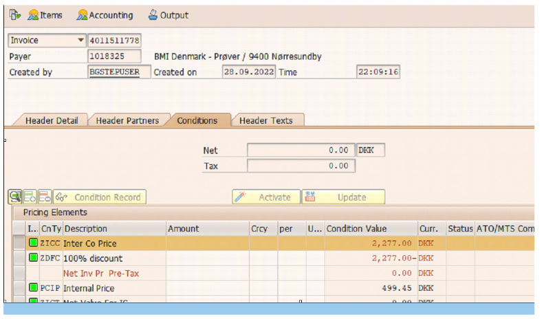

## Objective:

The objective of this report is to identify patterns in the missing data from the downloaded information provided by BI team which covers **2022 and YTD Aug 2023**:

1. MATERIALS - which types of products are missing COGs data?
2. PLANTS - is this specific to plants?
3. TIME - are the issue timing related?

## Actionable Insights:

1. The insights from the above will help us raise awareness on the importance of implementing and following **the right process**. It will help us zoom in on specific plants and products areas so we can resolve them in priority order.
2. The final section of the report will help USERS of Commercial Dashboard to understand where they need to show caution. We have provided significance using INV QTY so it is relative. Not all the data is incorrect, for example 1 Material missing COGs in one time period will not materially impact the overall metrics,

**REMEMBER: WE CANNOT CORRECT THE DATA IN RETROSPECT.**

## Analysis by Country - Denmark

### Dataframe

|  | Billing Doc | Sales Org | Material | P4_id | P4 | P6 | Plant | YPR | Invoice Quantity | COGs Value |
| --- | --- | --- | --- | --- | --- | --- | --- | --- | --- | --- |
| 0 | 4011480019 | DK10 | 10004712 | 10201B9 | Pitched Roofing Components | Glue and Sealants | 7K24 | 2022-01 | 15 | NaN |
| 1 | 4011480020 | DK10 | 10004712 | 10201B9 | Pitched Roofing Components | Glue and Sealants | 7K24 | 2022-01 | 10 | NaN |
| 2 | 4011480037 | DK10 | 10004712 | 10201B9 | Pitched Roofing Components | Glue and Sealants | 7K24 | 2022-01 | 6 | NaN |
| 3 | 4011480170 | DK10 | 10004712 | 10201B9 | Pitched Roofing Components | Glue and Sealants | 7K24 | 2022-01 | 50 | NaN |
| 4 | 4011480178 | DK10 | 10004710 | 10201B9 | Pitched Roofing Components | Glue and Sealants | 7K24 | 2022-01 | 2 | NaN |
| 5 | 4011480178 | DK10 | 10004713 | 10201B9 | Pitched Roofing Components | Glue and Sealants | 7K24 | 2022-01 | 2 | NaN |
| 6 | 4011480178 | DK10 | 10004712 | 10201B9 | Pitched Roofing Components | Glue and Sealants | 7K24 | 2022-01 | 4 | NaN |
| 7 | 4011480184 | DK10 | 10004484 | 10201B1 | Concrete | DK-B AND C | 7K24 | 2022-01 | 1 | NaN |
| 8 | 4011480212 | DK10 | 10004712 | 10201B9 | Pitched Roofing Components | Glue and Sealants | 7K24 | 2022-01 | 15 | NaN |
| 9 | 4011480213 | DK10 | 10004712 | 10201B9 | Pitched Roofing Components | Glue and Sealants | 7K24 | 2022-01 | 3 | NaN |

### Overview of Data

| Year | # of Unique Billing Documents | # of Unique Materials | # of Unique Plants | Sales |
| --- | --- | --- | --- | --- |
| 2022 | 2234 | 294 | 10 | 21M |
| YTD Aug 2023 | 608 | 50 | 7 | 2M |
| Total | 2842 | 315 | 10 | 23M |

### Relationship in Data - Materials by Plants:

| No. of Plants | No. of Materials | Percentage of Materials |
| --- | --- | --- |
| 1 | 281 | 89 % |
| 2 | 28 | 9 % |
| 3 | 4 | 1 % |
| 4 | 2 | 1 % |
| Total | 315 | 100 % |

### Observations:

- There are a total of 315 unique materials across 2022 and YTD Aug 2023.
- Most materials are exclusive to 1 Plant - **281 - 89%**
- Although there are only **11%** of materials that are associated with more than 1 plants, there are 34 such materials which is not a negligible number.

#### We will have to divide this analysis in two parts where first part will focus on materials unique to only one plant whereas the second part will analyze materials occurring across plants.

## Part A: Materials Exclusive to 1 Plant (89%)

Given the high concentration of Materials exclusively to 1 Plant , it makes it easier to better understand if there are any time related issues.

### Relationship in Data - Materials by frequency of occurrence in time periods

Of the **281 Materials** that are exclusive to **1 Plant**, here is a distribution by time period:

| No. of YPRs | No. of Materials | Percentage of Materials |
| --- | --- | --- |
| 1 | 180 | 64 % |
| 2 | 62 | 22 % |
| 3 | 22 | 8 % |
| 4 | 5 | 2 % |
| 5 | 2 | 1 % |
| 6 | 4 | 1 % |
| 10 | 1 | 0 % |
| 11 | 2 | 1 % |
| 13 | 1 | 0 % |
| 14 | 1 | 0 % |
| 18 | 1 | 0 % |
| Total | 281 | 100 % |

### Observations:

- There are 180 materials i.e. 64% out of 281 that are unique to a time period in the data.
- Also, 101 materials are such that they occur across multiple time periods.

### Part A (i): Materials Exclusive to 1 Time Period (64%)

Let’s first focus in on **180 materials which are unique to only one plant and only occur in one time period and, see them by their plants and the actual time period.**

| YPR | 7K20 | 7K21 | 7K23 | 7K24 | 7KBA | DK10 | DK11 | DK14 | DKBA | Total |
| --- | --- | --- | --- | --- | --- | --- | --- | --- | --- | --- |
| 2023-08 | 1 | 3 | nan | 1 | nan | nan | nan | nan | nan | 5 |
| 2023-07 | 1 | 1 | nan | nan | nan | nan | nan | nan | nan | 2 |
| 2023-05 | 3 | nan | nan | 1 | nan | nan | nan | nan | nan | 4 |
| 2023-04 | 1 | nan | nan | nan | nan | nan | nan | nan | nan | 1 |
| 2023-03 | 1 | nan | nan | nan | 1 | nan | nan | nan | nan | 2 |
| 2023-01 | nan | nan | nan | nan | 1 | nan | nan | nan | nan | 1 |
| 2022-12 | nan | nan | nan | nan | 1 | 1 | nan | nan | nan | 2 |
| 2022-11 | 1 | nan | nan | nan | 2 | nan | nan | 1 | nan | 4 |
| 2022-10 | nan | nan | nan | 1 | 1 | nan | 1 | nan | nan | 3 |
| 2022-09 | nan | 1 | nan | nan | 2 | 1 | nan | nan | nan | 4 |
| 2022-08 | 1 | 1 | nan | 2 | 9 | nan | nan | nan | 1 | 14 |
| 2022-07 | 1 | nan | nan | nan | 7 | nan | 1 | 1 | 2 | 12 |
| 2022-06 | 2 | 1 | nan | 1 | 15 | nan | nan | 3 | 6 | 28 |
| 2022-05 | nan | nan | nan | nan | 17 | nan | nan | nan | 1 | 18 |
| 2022-04 | 4 | nan | 1 | nan | 7 | nan | 1 | nan | 2 | 15 |
| 2022-03 | 2 | nan | nan | nan | 11 | 2 | nan | nan | 3 | 18 |
| 2022-02 | nan | nan | nan | nan | 10 | 17 | 1 | 12 | 2 | 42 |
| 2022-01 | nan | nan | nan | 5 | nan | nan | nan | nan | nan | 5 |
| Total | 18 | 7 | 1 | 11 | 84 | 21 | 4 | 17 | 17 | 180 |

### Observations:

- Out of the total 180 materials, more than 85% are covered by the plants:
  - 7KBA - 84 (46.7%)
  - DK10 - 21 (11.7%)
  - 7K20 - 18 (10%)
  - DK14 - 17 (9.4%)
  - DKBA - 17 (9.4%)

Let’s focus in on these 5 Plants and look at it by P4 groups:

| P4 | 7K20 | 7KBA | DK10 | DK14 | DKBA | Total | Total Invoice Quantity |
| --- | --- | --- | --- | --- | --- | --- | --- |
| Flat Roofing Components | nan | 13 | nan | nan | 5 | 18 | 2416 |
| Pitched Roofing Components | 3 | 14 | 19 | 14 | 4 | 54 | 1317 |
| Clay | 12 | nan | nan | 2 | nan | 14 | 912 |
| Other | 3 | 9 | nan | nan | 1 | 13 | 486 |
| Building Membranes | nan | 10 | nan | nan | 6 | 16 | 180 |
| Bitumen Shingles | nan | 4 | nan | nan | nan | 4 | 88 |
| Other_L4 | nan | 1 | nan | nan | nan | 1 | 16 |
| Bitumen Pitched Membranes | nan | 1 | nan | nan | nan | 1 | 8 |
| Scaffold Sheeting & Tarpaulins | nan | 2 | nan | nan | nan | 2 | 5 |
| Metal | nan | nan | 1 | nan | nan | 1 | 1 |
| Returnable Pallets | nan | 2 | nan | nan | nan | 2 | 0 |
| Bitumen | nan | 28 | 1 | 1 | 1 | 31 | -206 |

### Observations:

- Considering all **5** plants, the key areas to address missing COGs are **Flat Roofing Components, Pitched Roofing Components, Clay, Other, Bitumen & Building Membranes**. The area **Flat Roofing Components** impacts reporting the most given the invoice quantity.

Using the below tree map you can investigate by plant to a more detailed level:

[interactive chart not shown]

### Part A (ii): Materials Shared across Time Periods (36%)

- We will now focus on the materials that are unique to a plant but occur across multiple time periods

| No. of YPRs | No. of Materials | Percentage of Materials |
| --- | --- | --- |
| 1 | 180 | 64 % |
| 2 | 62 | 22 % |
| 3 | 22 | 8 % |
| 4 | 5 | 2 % |
| 5 | 2 | 1 % |
| 6 | 4 | 1 % |
| 10 | 1 | 0 % |
| 11 | 2 | 1 % |
| 13 | 1 | 0 % |
| 14 | 1 | 0 % |
| 18 | 1 | 0 % |
| Total | 281 | 100 % |

There are total **101** materials that occur in **multiple time periods**

#### Let’s take a closer look at these by Plant and Product Hierarchy P4:

| P4 | 7K21 | 7K24 | 7KBA | DK10 | DK11 | DK14 | DKBA |
| --- | --- | --- | --- | --- | --- | --- | --- |
| Bitumen | 2 | 0 | 28 | 0 | 0 | 0 | 0 |
| Bitumen Shingles | 0 | 0 | 1 | 0 | 0 | 0 | 0 |
| Bridge Decking | 1 | 0 | 2 | 0 | 0 | 0 | 0 |
| Building Membranes | 0 | 0 | 9 | 0 | 1 | 0 | 3 |
| Flat Roofing Components | 1 | 0 | 11 | 0 | 2 | 0 | 4 |
| Metal | 0 | 0 | 0 | 3 | 0 | 0 | 0 |
| Other | 0 | 0 | 1 | 0 | 0 | 0 | 1 |
| Pitched Roofing Components | 1 | 3 | 10 | 1 | 0 | 6 | 4 |
| Returnable Pallets | 1 | 0 | 0 | 0 | 0 | 0 | 0 |
| Scaffold Sheeting & Tarpaulins | 0 | 0 | 1 | 0 | 0 | 0 | 2 |
| Services | 0 | 0 | 0 | 2 | 0 | 0 | 0 |

### Observations:

- The key areas to focus on are **Bitumen, Flat Roofing Components, Pitched Roofing Components & Building Membranes** and for all those four P4 Product Hierarchies, the plant to focus on is **7KBA**.

Use the below tree map to investigate the actual materials navigating through different levels:

[interactive chart not shown]

## Part B: Materials Shared across Plants (11%)

We will now understand the remaining part of the data:

|  | No. of Plants | No. of Materials | Percentage of Materials |
| --- | --- | --- | --- |
| 0 | 1 | 281 | 89 % |
| 1 | 2 | 28 | 9 % |
| 2 | 3 | 4 | 1 % |
| 3 | 4 | 2 | 1 % |
| 4 | Total | 315 | 100 % |

There are total **34** materials that have **two or more plants associated with them.**

### Let’s take a closer look by Timing:

| Month | 2022 | 2023 |
| --- | --- | --- |
| 01 | nan | 7 |
| 02 | 4 | 7 |
| 03 | 11 | 12 |
| 04 | 14 | 10 |
| 05 | 22 | 10 |
| 06 | 26 | 9 |
| 07 | 20 | 7 |
| 08 | 23 | 8 |
| 09 | 18 | nan |
| 10 | 17 | nan |
| 11 | 14 | nan |
| 12 | 13 | nan |

### Observations:

- The materials are not concentrated in any one particular month but we can say that there is less to no concentration in in the year 2022 for months January & February and for months September to December in the year 2023. Thus, we will focus on the remaining time periods.

The distribution of those materials present in the time periods - 2022 - March to December and 2023 - January to August against the respective Product Hierarchy P4 groups is given below:

| P4 | 7K20 | 7K21 | 7KBA | DK01 | DK10 | DK11 | DK14 | DKBA |
| --- | --- | --- | --- | --- | --- | --- | --- | --- |
| Bitumen | 0 | 3 | 4 | 0 | 0 | 0 | 0 | 0 |
| Bitumen Shingles | 0 | 1 | 1 | 0 | 0 | 0 | 0 | 0 |
| Building Membranes | 0 | 0 | 0 | 0 | 1 | 0 | 0 | 1 |
| Flat Roofing Components | 0 | 1 | 1 | 0 | 0 | 1 | 0 | 3 |
| Metal | 0 | 1 | 0 | 0 | 2 | 1 | 0 | 0 |
| Other | 2 | 0 | 3 | 0 | 0 | 0 | 0 | 1 |
| Pitched Roofing Components | 1 | 2 | 3 | 0 | 0 | 0 | 0 | 0 |
| Returnable Pallets | 1 | 1 | 2 | 0 | 0 | 0 | 0 | 0 |
| Services | 0 | 0 | 0 | 1 | 8 | 10 | 8 | 8 |

### Observations:

*There are **14** materials in the above mentioned plants and time periods in Services category group. Let's look at those materials individually by their net invoice quantity:*

| Plant | YPR Material | 2022-03 | 2022-04 | 2022-05 | 2022-06 | 2022-07 | 2022-08 | 2022-09 | 2022-10 | 2022-11 | 2022-12 | 2023-01 | 2023-02 | 2023-03 | 2023-04 | 2023-05 | 2023-06 | 2023-07 | 2023-08 | Total Net Invoice Quantity |
| --- | --- | --- | --- | --- | --- | --- | --- | --- | --- | --- | --- | --- | --- | --- | --- | --- | --- | --- | --- | --- |
| DK10 | 30000035 | 0 | 1 | -1 | 0 | -1 | 0 | 0 | 0 | 0 | 120 | -1 | 0 | 0 | 0 | -1 | -1 | -1 | 0 | 115 |
|  | 30000037 | 0 | 0 | 0 | -1 | 0 | 0 | 0 | 0 | 0 | 0 | 0 | 0 | 0 | 0 | 0 | 0 | 0 | 0 | -1 |
|  | 30000038 | 0 | 0 | 0 | -1 | 0 | -1 | -1 | -1 | -1 | -1 | 0 | 0 | 0 | -1 | 5201 | 0 | -1 | -1 | 5192 |
|  | 30000040 | 1 | 0 | 0 | 0 | 0 | 0 | 0 | 0 | 0 | 3 | 0 | 0 | 0 | 0 | 0 | 0 | 0 | 0 | 4 |
|  | 30000041 | 1 | 0 | 0 | 0 | 0 | 0 | 0 | 0 | 0 | 0 | 0 | 0 | 0 | 0 | 0 | 0 | 1 | 0 | 2 |
|  | 30000042 | 1 | 0 | 0 | 0 | 0 | 0 | 0 | 0 | 0 | 0 | 0 | 0 | 0 | 0 | 0 | 0 | 0 | 0 | 1 |
|  | 30000043 | 0 | 1 | 0 | 0 | 0 | 0 | 1 | 0 | 0 | 2 | 0 | 0 | 0 | 0 | 0 | 0 | 0 | 0 | 4 |
|  | 30000044 | 4 | 0 | 0 | 0 | 3 | 3 | 0 | 0 | 3 | 0 | 0 | 0 | 0 | 0 | 0 | 0 | 0 | 0 | 13 |
| DK11 | 30000035 | 0 | 0 | 0 | 0 | 0 | 0 | 0 | 0 | 0 | 0 | -1 | -1 | 0 | 0 | 0 | 0 | -1 | 0 | -3 |
|  | 30000037 | 0 | 0 | 0 | 0 | 0 | 0 | -1 | 0 | 0 | -1 | 0 | 0 | 0 | 0 | 0 | 0 | 0 | 0 | -2 |
|  | 30000038 | 0 | -40 | 0 | 0 | -6 | 0 | -578 | -1 | 0 | -1 | 0 | -1 | -1 | -1 | -1 | -1 | -1 | -1 | -633 |
|  | 30000042 | 1 | 0 | 0 | -2 | 0 | 2 | -2 | 0 | 0 | 0 | 0 | 0 | 0 | 0 | 0 | 0 | 0 | 2 | 1 |
|  | 30000044 | 0 | 0 | 0 | 0 | 0 | 0 | 0 | 0 | 0 | 0 | 0 | 0 | 0 | 0 | 0 | 0 | 0 | 0 | 0 |
|  | 30000045 | 0 | 0 | 0 | -1 | 1 | 0 | 0 | -2 | 0 | 0 | 0 | 0 | -3 | 0 | 0 | 3 | 0 | 0 | -2 |
|  | 30000046 | 0 | 0 | 0 | 0 | 2 | -4 | 0 | 0 | 0 | 0 | 0 | 0 | 3 | 0 | 2 | -2 | 0 | 0 | 1 |
|  | 30000050 | 1 | -1 | 0 | 0 | 1 | -1 | 0 | 0 | 0 | 0 | 0 | 0 | 0 | 0 | 0 | 0 | 0 | 0 | 0 |
|  | 30000051 | 0 | 1 | 0 | 1 | 0 | 0 | 0 | -1 | 0 | 0 | 0 | 0 | 0 | 0 | -1 | 1 | 0 | -1 | 0 |
|  | 30000093 | 1 | 0 | 0 | -3 | 0 | 3 | 0 | 1 | -2 | 0 | 0 | -2 | 2 | 0 | 0 | 0 | 0 | 0 | 0 |
| DK14 | 30000016 | 0 | 0 | 0 | 0 | 0 | -1 | -1 | 0 | 0 | 0 | 0 | 0 | 0 | 0 | 0 | 0 | 0 | 0 | -2 |
|  | 30000035 | -1 | 0 | 0 | 0 | 0 | 0 | 0 | 0 | 0 | 0 | 0 | 0 | 0 | 0 | 0 | 0 | 0 | 0 | -1 |
|  | 30000038 | 0 | 0 | 0 | 0 | 0 | 0 | 0 | -1 | 0 | -1 | -1 | -1 | -1 | -1 | -1 | -1 | 0 | 0 | -8 |
|  | 30000040 | 1 | 0 | 0 | 0 | 3 | 1 | 4 | 1 | 0 | 0 | 0 | 0 | 1 | 0 | 0 | 0 | 0 | 0 | 11 |
|  | 30000041 | 3 | 0 | -1 | 0 | -1 | 0 | 0 | 0 | -1 | 3 | 0 | 0 | 0 | -1 | -1 | 0 | 0 | 0 | 1 |
|  | 30000042 | 1 | 0 | 0 | -1 | 0 | 0 | 0 | 0 | 0 | 0 | 0 | 0 | 0 | 0 | 0 | 2 | 0 | 0 | 2 |
|  | 30000043 | 2 | 1 | -2 | 2 | 0 | 1 | 2 | 2 | -2 | 5 | 0 | 0 | 1 | 0 | 1 | -3 | 0 | 0 | 10 |
|  | 30000044 | 4 | 0 | 7 | 3 | 3 | 3 | -4 | 3 | 0 | 0 | 0 | 5 | 0 | 4 | 2 | 0 | 0 | 1 | 31 |
| DKBA | 30000037 | 0 | 0 | -1 | -1 | 0 | 0 | 0 | 0 | 0 | 0 | 0 | 0 | 0 | 0 | 0 | 0 | 0 | 0 | -2 |
|  | 30000038 | -20 | 0 | 0 | -10 | 0 | 0 | 0 | 0 | 0 | 0 | 0 | 0 | 0 | 0 | 0 | 0 | 0 | 0 | -30 |
|  | 30000042 | 0 | 1 | -1 | 0 | 0 | 0 | 0 | 0 | 0 | 0 | 0 | 0 | 0 | 0 | 0 | 0 | 0 | 0 | 0 |
|  | 30000045 | 0 | 0 | 0 | -1 | 0 | 0 | 0 | 0 | 0 | 0 | 0 | 0 | 0 | 0 | 0 | 0 | 0 | 0 | -1 |
|  | 30000046 | 0 | 0 | -3 | 0 | 0 | 0 | 0 | 0 | 0 | 0 | 0 | 0 | 0 | 0 | 0 | 0 | 0 | 0 | -3 |
|  | 30000050 | 0 | 1 | 0 | -1 | 0 | 0 | 0 | 0 | 0 | 0 | 0 | 0 | 0 | 0 | 0 | 0 | 0 | 0 | 0 |
|  | 30000051 | 0 | 0 | -1 | 0 | 0 | 0 | 0 | 0 | 0 | 0 | 0 | 0 | 0 | 0 | 0 | 0 | 0 | 0 | -1 |
|  | 30000093 | 0 | 0 | 0 | 0 | 1 | 0 | 0 | 0 | 0 | 0 | 0 | 0 | 0 | 0 | 0 | 0 | 0 | 0 | 1 |

## Part C: Helping Users of Commercial Dashboards

This final section of this report will help USERS of Commercial Dashboard to understand where they need to show caution. We have provided significance using INV QTY so it is relative. Not all the data is incorrect, for example 1 Material missing COGs in one time period will not materially impact the overall metrics.

**REMEMBER: WE CANNOT CORRECT THE DATA IN RETROSPECT.**

### Net Invoice Quantity for P4 groups

| P4 | Net Invoice Quantity | Total Materials |
| --- | --- | --- |
| Metal | 7676 | 8 |
| Bitumen | 6262 | 69 |
| Flat Roofing Components | 5815 | 42 |
| Pitched Roofing Components | 4838 | 86 |
| Services | 4113 | 19 |
| Building Membranes | 2956 | 30 |
| Other | 1003 | 19 |
| Clay | 907 | 15 |
| Scaffold Sheeting & Tarpaulins | 306 | 5 |
| Concrete | 260 | 5 |
| Bridge Decking | 168 | 3 |
| Bitumen Shingles | 119 | 6 |
| Other_L4 | 16 | 1 |
| Bitumen Pitched Membranes | 8 | 1 |
| Returnable Pallets | -818 | 6 |

[interactive chart not shown]

### Observations:

- The highest Net Invoice Value for a P4 level is for **Metal - 7676.** However, there are only 8 unique materials in that category which means that individual values of Invoice Quantity is very high. A similar case is seen for category **Services**.
- Apart from that, **Bitumen, Flat Roofing Components, & Pitched Roofing Components** have high volume in terms of number of materials and are also significant in terms of Invoice Quantity.
- One of the most important observations is that, although for **Scaffold Sheeting & Tarpaulins** the net invoice quantity is very low at the P4 level, when we break it down by Time Periods we see large values for June 2022 and March 2022. However, as these values mostly cancel out each other, the net becomes insignificant while looking from just P4 level.

When it appears as negative invoice qty, we have potentially recorded negative sales say -100 but potentially not recorded the product cost(let’s assume 50) which means a P&L hit of -100 instead of -50.

That is not to say is what actually happened as we may have made some accounting adjustments BUT this is however it appears when looking at the data from source billing docs and cost of goods from S4 to BI(in the dashboards)

Using the below tree map you can investigate the net invoice quantity for individual materials:

[interactive chart not shown]